# White Wine Quality

### Plot 2

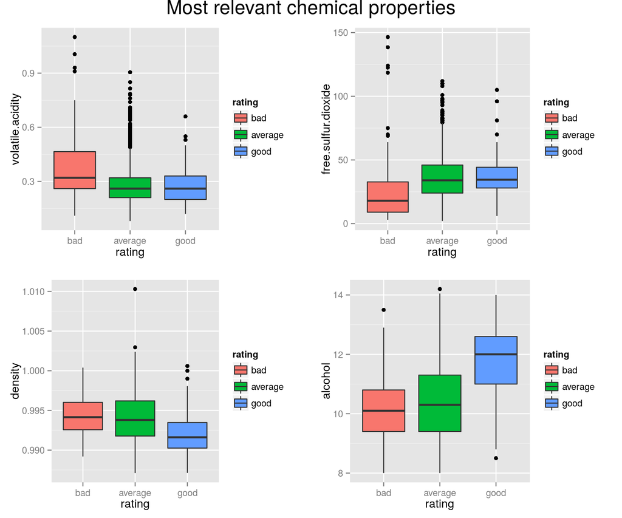

This plot shows the main contributors to the differences in qualities of Vinho Verde wines. It was created with the entire dataset of all wines, but according to their ranks. The bad wines (denoted in pink) are those ranked 3 and 4. The average wines (denoted in green) are those ranked 5, 6 and 7. Finally, the good wines (denoted in blue) are those ranked as 8 and 9.

The top two plots are most highly correlated with bad wines. In these two plots the bad wines show far more variance that even the middle tier wines, which is interesting given how many wines are in the middle tier. There are 182 wines in the the bad group while there are 3059 wines in the agerage group. Above average `volatile.acidity` appears to be a potentially strong predictor of bad wine.

In the same vein, lower than average `free.sulfur.dioxide` is a potentially still stronger predictor of low quality wine. In this plot we see slightly more variation in the middle quartiles of the average tier wines than in the first plot, however, the bad wines exhibit more variance that the middle tier wines (just as in the last plot).

The next two plots are the potential predictors of high quality wines. We can see from these plots that average and bad wines have similar medians and are quite a bit higher in `density` than good wines.

Far more remarkable is the `alcohol` plot. The median alcohol content of good wines is almost precisely 12% where the median alcohol content of bad wines is only slightly above 10%. In this plot, the good wines appear to be a head taller than the bad wines.

It hears mentioning, however, that if I were building an actual prediction model concerning `density` and `alcohol`, I would be careful to consider the correlation between these two variables, which as I mentioned earlier is -0.803.

# Plot 3

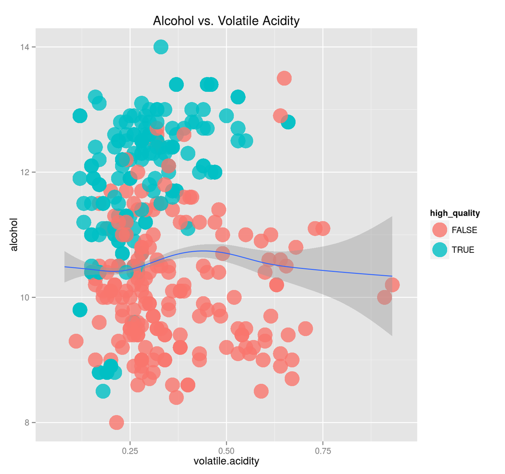

In this plot, which again plots only the best and worst wines, we can see clearly that the combination of high `alcohol` and low `volatile.acidity` are characteristic of the good wines and that the opposite is true for bad wines.

There is once again substantially more variation among the bad wines. Given that there are nearly identical numbers in the two sets (182 bad and 180 good), this variation exhibited in bad wines continues to be interesting.

# Reflection

It is very important to understand that this data is of the white variety of Vinho Verde, a realtively unique Portugese wine. It is not representative of white wines typically and any conclusions drawn here are unlikely to apply to white wines generally.

Additionally, according to the short research I performed on the topic, many people believe that wines above 12% alcohol are not truly Vinho Verde, but a different type of wine altogether. In support of their arguments, they state that Portugese law actually requires Vinho Verde to be under 12% alcohol. I did not find out if this is actually the law, but it was brought up in at least a couple of sources. In addition, the higher alcohol wines are not sparkling. The traditional Vinho Verde wines were naturally carbonated, but this practice is atypical now. Currently the wines are slightly carbonated during the bottling process. The higher end wines are not artificially carbonated.

To this end, I thought it would have made for a better dataset, as well for an easier classification problem, if a carbonation factor was included.

# Resources

- [Vihno Verde on Wikipedia](https://en.wikipedia.org/wiki/Vinho_Verde)
- [Quick-R](http://www.statmethods.net/management/merging.html)
- [Stack Overflow](http://stackoverflow.com/questions/12328056/how-do-i-delete-rows-in-a-data-frame)
- [Wall Street Journal](http://www.wsj.com/articles/the-elegant-serious-side-of-vinho-verde-1408725508)